# categorical data – SDSS workshop

2023-05-23

## Numeric data

```r
library(ade4)
data("clementines")
str(clementines)
```

```
## 'data.frame':    15 obs. of  20 variables:
##  $ a1 : num  18.6 37.6 71.6 94.2 100.2 ...
##  $ a2 : num  17 38.2 67.8 106.8 64.2 ...
##  $ a3 : num  19 36.2 90.4 110.9 83.4 ...
##  $ a4 : num  6 48.6 77 115.5 94.1 ...
##  $ a5 : num  15.8 43.6 81.6 133 87.6 ...
##  $ a6 : num  0 22.8 36.6 111.2 54.8 ...
##  $ a7 : num  6.2 31 62 101.5 66.8 ...
##  $ a8 : num  5 30.2 31.1 89.7 53.5 ...
##  $ a9 : num  7.2 27 65 124.1 104.9 ...
##  $ a10: num  0 25.8 60.8 69.5 81.9 ...
##  $ a11: num  8 19.4 60.2 102.7 56.5 ...
##  $ a12: num  15 38 71.4 106.9 67.4 ...
##  $ a13: num  2.8 35.8 66.6 121.5 67.7 ...
##  $ a14: num  4.4 35.4 48 120.7 41 ...
##  $ a15: num  6.6 34.8 52 100.6 78 ...
##  $ a16: num  4 28.6 34.1 101.5 40.1 ...
##  $ a17: num  2.4 41.2 30 116.4 11.2 ...
##  $ a18: num  9.6 24.4 54 103.9 67.4 ...
##  $ a19: num  0 33.8 47.6 111.7 79.7 ...
##  $ a20: num  2.2 31.2 57.6 127.7 65.5 ...
```

## Categorical data

```r
library(fivethirtyeight)
str(food_world_cup[,1:12])
```

```
## Classes 'tbl_df', 'tbl' and 'data.frame':    1373 obs. of  12 variables:
##  $ respondent_id   : num  3.31e+09 3.31e+09 3.31e+09 3.31e+09 3.31e+09 ...
##  $ knowledge       : Ord.factor w/ 4 levels "Novice"<"Intermediate"<..: 2 1 2 1 1 3 1 3 1 1 ...
##  $ interest        : Ord.factor w/ 4 levels "Not at all"<"Not much"<..: 3 3 4 2 2 4 3 4 2 3 ...
##  $ gender          : chr  "Male" "Male" "Male" "Male" ...
##  $ age             : Factor w/ 4 levels "18-29","30-44",..: 1 1 2 3 2 2 3 3 2 NA ...
##  $ household_income: Factor w/ 5 levels "$0 - $24,999",..: 4 4 3 1 2 3 NA 1 3 NA ...
##  $ education       : Ord.factor w/ 5 levels "Less than high school degree"<..: 1 3 5 1 2 5 2 3 3 NA ...
##  $ location        : chr  "West South Central" "West South Central" "Pacific" "New England" ...
##  $ algeria         : chr  "N/A" "N/A" "3" "N/A" ...
##  $ argentina       : chr  "3" "N/A" "4" "3" ...
##  $ australia       : chr  "5" "3" "N/A" "N/A" ...
##  $ belgium         : chr  "4" "3" "3" "3" ...
```

## Warnings

> - words are hard to work with!
> - not a lot of options (esp. for 1 dimension): bar plot, Cleveland dot plot
> - data cleaning takes more time
> - main choices: *which* categories to plot, *order* of categories

## Types of data

> - nominal does not have a fixed category order
> - ordinal does have a fixed category order
> - (“real”) discrete, small ## of possibilities
> - Not always clearcut: nominal vs. ordinal, ordinal vs. discrete, etc.
> - Sometimes numbers = nominal, not discrete

## Ordinal data

Sort in logical order of the categories (left to right)

```r
library(tidyverse)
```

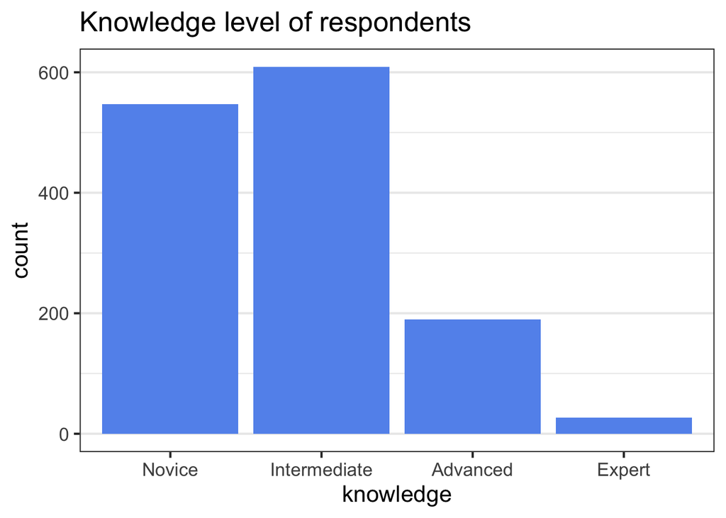

```r
ggplot(food_world_cup, aes(knowledge)) +
    geom_bar(fill = "cornflowerblue") +
    ggtitle("Knowledge level of respondents") +
    theme_bw(16) +
    theme(panel.grid.major.x = element_blank())
```

## Ordinal data

Sort in logical order of the categories (starting at bottom OR top)

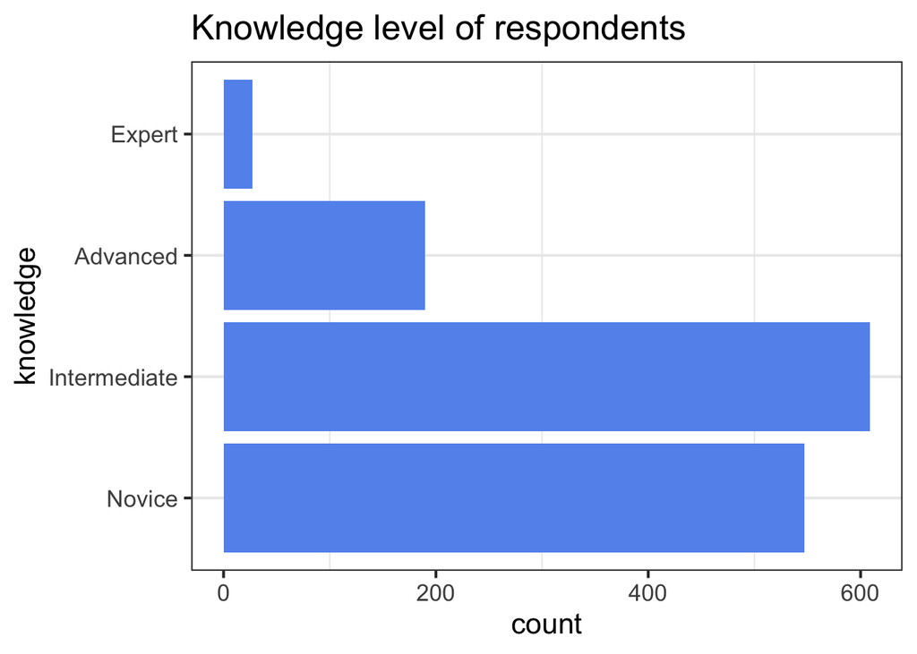

```r
ggplot(food_world_cup, aes(knowledge)) +
    geom_bar(fill = "cornflowerblue") +
    coord_flip() +
    ggtitle("Knowledge level of respondents") +
    theme_bw(16) +
    theme(panel.grid.major.x = element_blank())
```

## Nominal data

Sort from highest to lowest count (left to right, or top to bottom)

```r
student <- read_csv("student_data.csv")
```

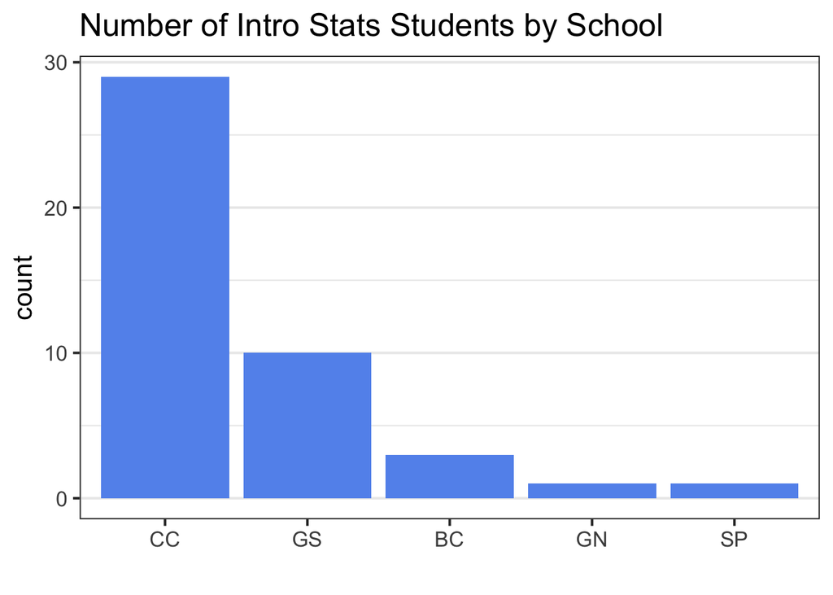

```r
## See "School Codes and Descriptions" in SSOL help menu

ggplot(student, aes(fct_infreq(School))) +
    geom_bar(fill = "cornflowerblue") +
    ggtitle("Number of Intro Stats Students by School") +
    xlab("") +
    theme_bw(16) +
    theme(panel.grid.major.x = element_blank())
```

## Nominal data

… or top to bottom

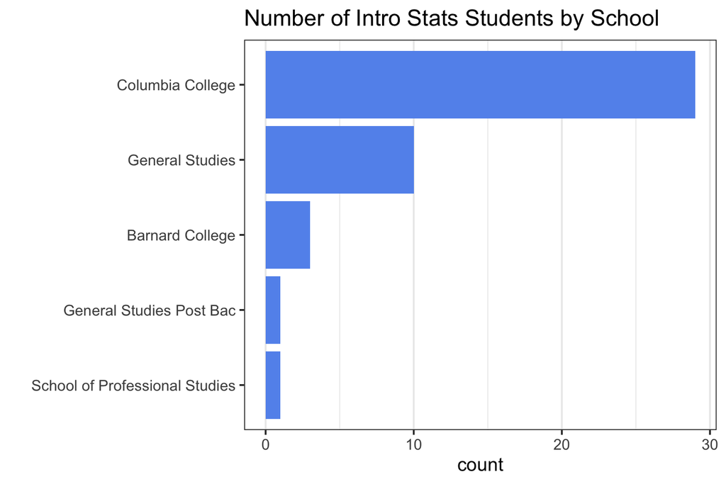

```r
student$School <- fct_recode(student$School,
                             `Barnard College`= "BC",
                             `Columbia College` = "CC",
                             `General Studies Post Bac` = "GN",
                             `General Studies` = "GS",
                             `School of Professional Studies` = "SP")


ggplot(student, aes(fct_rev(fct_infreq(School)))) +
  geom_bar(fill = "cornflowerblue") +
  coord_flip() +
  ggtitle("Number of Intro Stats Students by School") +
  xlab("") +
  theme_bw(14) +
  theme(panel.grid.major.y = element_blank())
```

## Discrete data

```r
library(vcd)
```

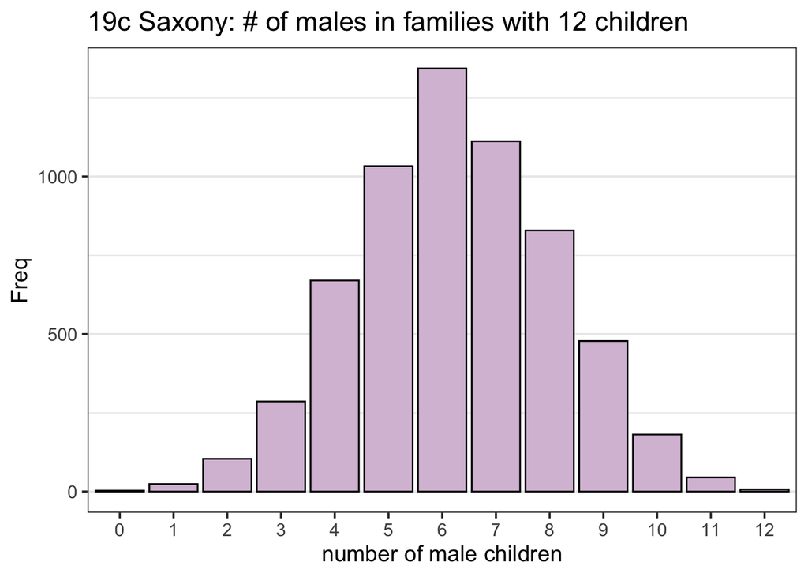

```r
df <- data.frame(Saxony)
ggplot(df, aes(x = nMales, y = Freq)) +
  geom_col(color = "black", fill = "thistle") +
  ggtitle("19c Saxony: # of males in families with 12 children") +
  xlab("number of male children") +
  theme_bw(14) +
  theme(panel.grid.major.x = element_blank())
```

## Two geoms for bar charts

> - Binned data (has a count column) `geom_col()`
> - Unbinned data (no count column) `geom_bar()`

## `geom_col()`

> - Requires an **x** and **y**
> - Intended to be used with one **continuous** and one **discrete** variables but other combinations may also work

## Look at the data

```r
df_binned <- data.frame(state = c("CA", "NY", "TX"),
                        count = c(4, 3, 2))
df_binned
```

```
##   state count
## 1    CA     4
## 2    NY     3
## 3    TX     2
```

## Bar chart with binned data

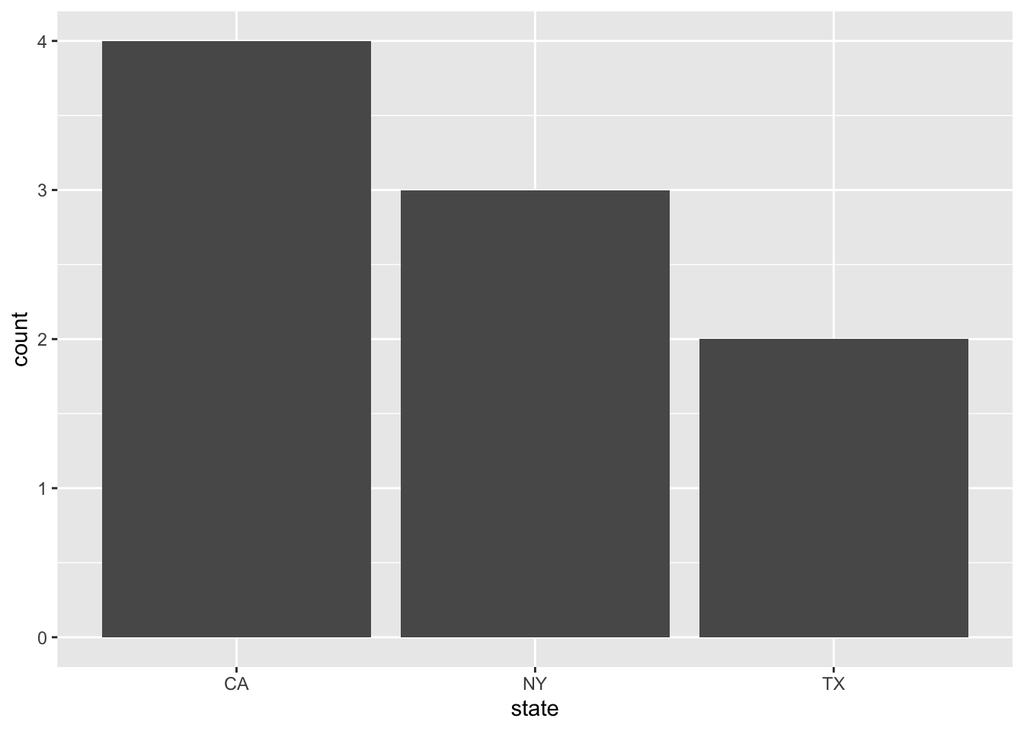

```r
ggplot(df_binned, aes(x = state, y = count)) +
  geom_col()
```

## `geom_bar()`

> - Requires an **x** or **y**
> - Intended to be used with one **discrete** variable

## Look at the data

```r
df_unbinned <- data.frame(state = c("NY", "CA", "TX", "NY", "CA", "CA", "TX", "CA", "NY"))
str(df_unbinned)
```

```
## 'data.frame':    9 obs. of  1 variable:
##  $ state: chr  "NY" "CA" "TX" "NY" ...
```

## Bar chart with unbinned data

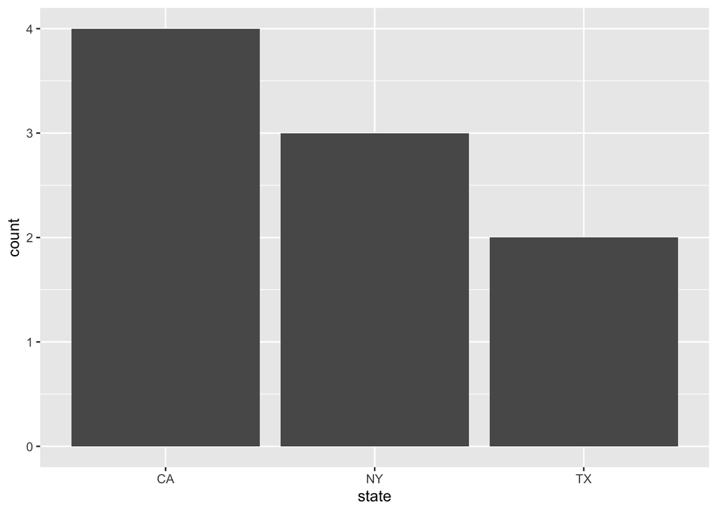

```r
ggplot(df_unbinned, aes(x = state)) +
  geom_bar()
```

# Cleveland dot plot

## Cleveland dot plot

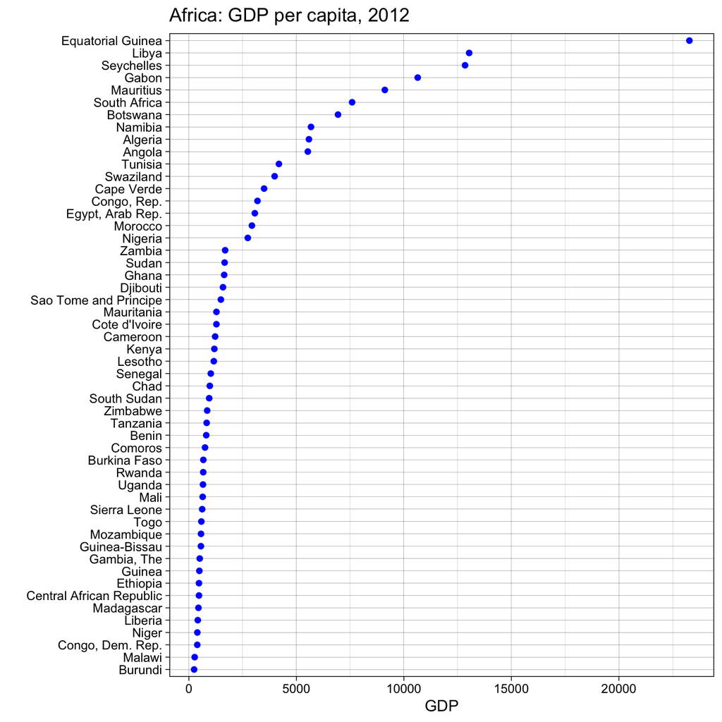

```r
## Cleveland Dot Plot theme
world <- read_csv("countries2012.csv")
africa <- world |>
  filter(CONTINENT == "Africa")
ggplot(africa, aes(x = GDP, y = fct_reorder(COUNTRY, GDP))) +
  geom_point(color = "blue") +
  ggtitle("Africa: GDP per capita, 2012") +
  ylab("") +
  theme_linedraw() ## works well for dotplots
```

## Cleveland dot plot with multiple dots

Sorted by 1997 fatality rate

```r
library(AER)
```

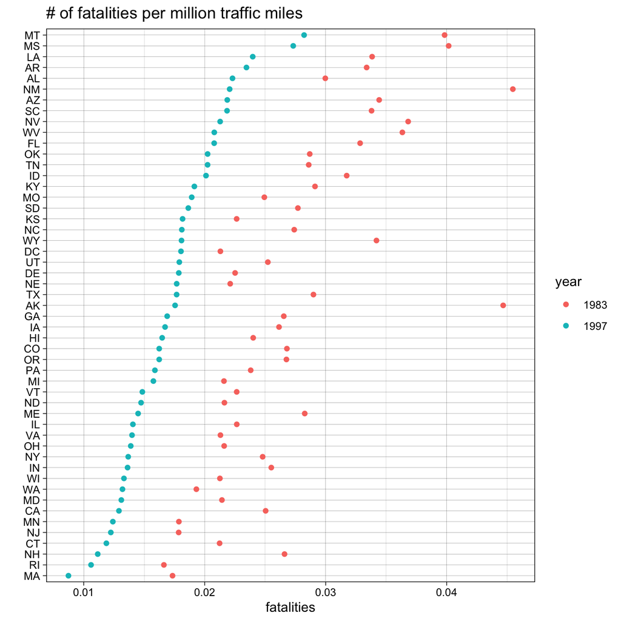

```r
data("USSeatBelts")
belts <- USSeatBelts |>
  filter(year %in% c(1983, 1997)) |>
  select(state, year, fatalities)

## `fct_reorder2` --> double sort: year, then fatalities
ggplot(belts, aes(x = fatalities, y = fct_reorder2(state, year == 1997, fatalities,
                                                   .desc = FALSE), color = year)) +
  geom_point() +
  ggtitle("# of fatalities per million traffic miles") +
  ylab("") +
  theme_linedraw()
```